# Lending Club

[figure not shown]

#### Autores:

- Sergio Cañón Laíz
- Ignacio Ruiz de Zuazu Echevarría

## Objetivos del trabajo

El objetivo de este proyecto es el de construir un modelo de aprendizaje automático para predecir la probabilidad de que un préstamo se cancele a partir de diversos modelos. Para este trabajo se emplearán los datos proporcionados por Lending Club, en la que se nos aporta información sobre el prestatario y los préstamos concedidos.

### Librerías

```python
import pandas as pd
import numpy as np
import matplotlib.pyplot as plt
import seaborn as sns
from matplotlib import rcParams
from scipy import stats

# Para graficas en jupyter
%matplotlib inline
# Tamaño de las figuras
rcParams['figure.figsize'] = 14,6
```

## Dataset y variables

```python
loan_training_set1 = pd.read_csv('./data/01_raw/Loan_training_set_1_4.csv', sep = ',' , skiprows=1)
loan_training_set1.drop(loan_training_set1.index[105451], inplace=True)
loan_training_set1.drop(loan_training_set1.index[105451], inplace=True)
loan_training_set1
```

|  | id | member_id | loan_amnt | funded_amnt | funded_amnt_inv | term | int_rate | installment | grade | sub_grade | ... | hardship_payoff_balance_amount | hardship_last_payment_amount | disbursement_method | debt_settlement_flag | debt_settlement_flag_date | settlement_status | settlement_date | settlement_amount | settlement_percentage | settlement_term |
| --- | --- | --- | --- | --- | --- | --- | --- | --- | --- | --- | --- | --- | --- | --- | --- | --- | --- | --- | --- | --- | --- |
| 0 | 112435993 | NaN | 2300.0 | 2300.0 | 2300.0 | 36 months | 12.62% | 77.08 | C | C1 | ... | NaN | NaN | Cash | N | NaN | NaN | NaN | NaN | NaN | NaN |
| 1 | 112290210 | NaN | 16000.0 | 16000.0 | 16000.0 | 60 months | 12.62% | 360.95 | C | C1 | ... | NaN | NaN | Cash | N | NaN | NaN | NaN | NaN | NaN | NaN |
| 2 | 112436985 | NaN | 6025.0 | 6025.0 | 6025.0 | 36 months | 15.05% | 209.01 | C | C4 | ... | NaN | NaN | Cash | N | NaN | NaN | NaN | NaN | NaN | NaN |
| 3 | 112439006 | NaN | 20400.0 | 20400.0 | 20400.0 | 36 months | 9.44% | 652.91 | B | B1 | ... | NaN | NaN | Cash | N | NaN | NaN | NaN | NaN | NaN | NaN |
| 4 | 112438929 | NaN | 13000.0 | 13000.0 | 13000.0 | 36 months | 11.99% | 431.73 | B | B5 | ... | NaN | NaN | Cash | N | NaN | NaN | NaN | NaN | NaN | NaN |
| ... | ... | ... | ... | ... | ... | ... | ... | ... | ... | ... | ... | ... | ... | ... | ... | ... | ... | ... | ... | ... | ... |
| 105446 | 102556443 | NaN | 24000.0 | 24000.0 | 24000.0 | 60 months | 23.99% | 690.30 | E | E2 | ... | NaN | NaN | Cash | N | NaN | NaN | NaN | NaN | NaN | NaN |
| 105447 | 102653304 | NaN | 10000.0 | 10000.0 | 10000.0 | 36 months | 7.99% | 313.32 | A | A5 | ... | NaN | NaN | Cash | N | NaN | NaN | NaN | NaN | NaN | NaN |
| 105448 | 102628603 | NaN | 10050.0 | 10050.0 | 10050.0 | 36 months | 16.99% | 358.26 | D | D1 | ... | NaN | NaN | Cash | N | NaN | NaN | NaN | NaN | NaN | NaN |
| 105449 | 102196576 | NaN | 6000.0 | 6000.0 | 6000.0 | 36 months | 11.44% | 197.69 | B | B4 | ... | NaN | NaN | Cash | N | NaN | NaN | NaN | NaN | NaN | NaN |
| 105450 | 99799684 | NaN | 30000.0 | 30000.0 | 30000.0 | 60 months | 25.49% | 889.18 | E | E4 | ... | NaN | NaN | Cash | N | NaN | NaN | NaN | NaN | NaN | NaN |

105451 rows × 151 columns

```python
loan_training_set2 = pd.read_csv('./data/01_raw/Loan_training_set_2_4.csv', sep = ',' , skiprows=1)
loan_training_set2.drop(loan_training_set2.index[122701], inplace=True)
loan_training_set2.drop(loan_training_set2.index[122701], inplace=True)
loan_training_set2
```

|  | id | member_id | loan_amnt | funded_amnt | funded_amnt_inv | term | int_rate | installment | grade | sub_grade | ... | hardship_payoff_balance_amount | hardship_last_payment_amount | disbursement_method | debt_settlement_flag | debt_settlement_flag_date | settlement_status | settlement_date | settlement_amount | settlement_percentage | settlement_term |
| --- | --- | --- | --- | --- | --- | --- | --- | --- | --- | --- | --- | --- | --- | --- | --- | --- | --- | --- | --- | --- | --- |
| 0 | 118659541 | NaN | 33000.0 | 33000.0 | 33000.0 | 36 months | 7.21% | 1022.12 | A | A3 | ... | NaN | NaN | Cash | N | NaN | NaN | NaN | NaN | NaN | NaN |
| 1 | 119321612 | NaN | 40000.0 | 40000.0 | 40000.0 | 60 months | 15.05% | 952.65 | C | C4 | ... | NaN | NaN | Cash | N | NaN | NaN | NaN | NaN | NaN | NaN |
| 2 | 120122535 | NaN | 12000.0 | 12000.0 | 12000.0 | 36 months | 7.97% | 375.88 | A | A5 | ... | NaN | NaN | Cash | N | NaN | NaN | NaN | NaN | NaN | NaN |
| 3 | 119246018 | NaN | 7000.0 | 7000.0 | 7000.0 | 36 months | 7.97% | 219.26 | A | A5 | ... | NaN | NaN | Cash | N | NaN | NaN | NaN | NaN | NaN | NaN |
| 4 | 119374887 | NaN | 32000.0 | 32000.0 | 32000.0 | 36 months | 11.99% | 1062.71 | B | B5 | ... | NaN | NaN | Cash | N | NaN | NaN | NaN | NaN | NaN | NaN |
| ... | ... | ... | ... | ... | ... | ... | ... | ... | ... | ... | ... | ... | ... | ... | ... | ... | ... | ... | ... | ... | ... |
| 122696 | 110380307 | NaN | 6000.0 | 6000.0 | 6000.0 | 36 months | 23.88% | 235.02 | E | E2 | ... | NaN | NaN | Cash | N | NaN | NaN | NaN | NaN | NaN | NaN |
| 122697 | 110479222 | NaN | 20000.0 | 20000.0 | 20000.0 | 60 months | 26.30% | 602.37 | E | E5 | ... | NaN | NaN | Cash | N | NaN | NaN | NaN | NaN | NaN | NaN |
| 122698 | 109866673 | NaN | 35000.0 | 35000.0 | 35000.0 | 60 months | 30.89% | 1151.58 | G | G3 | ... | NaN | NaN | Cash | N | NaN | NaN | NaN | NaN | NaN | NaN |
| 122699 | 110394553 | NaN | 30775.0 | 30775.0 | 30525.0 | 60 months | 30.65% | 1008.00 | F | F4 | ... | NaN | NaN | Cash | N | NaN | NaN | NaN | NaN | NaN | NaN |
| 122700 | 109517381 | NaN | 18900.0 | 18900.0 | 18900.0 | 60 months | 30.94% | 622.44 | G | G4 | ... | NaN | NaN | Cash | N | NaN | NaN | NaN | NaN | NaN | NaN |

122701 rows × 151 columns

```python
loan_training_set3 = pd.read_csv('./data/01_raw/Loan_training_set_3_4.csv', sep = ',' , skiprows=1)
loan_training_set3.drop(loan_training_set3.index[235629], inplace=True)
loan_training_set3.drop(loan_training_set3.index[235629], inplace=True)
loan_training_set3
```

|  | id | member_id | loan_amnt | funded_amnt | funded_amnt_inv | term | int_rate | installment | grade | sub_grade | ... | hardship_payoff_balance_amount | hardship_last_payment_amount | disbursement_method | debt_settlement_flag | debt_settlement_flag_date | settlement_status | settlement_date | settlement_amount | settlement_percentage | settlement_term |
| --- | --- | --- | --- | --- | --- | --- | --- | --- | --- | --- | --- | --- | --- | --- | --- | --- | --- | --- | --- | --- | --- |
| 0 | 38098114 | NaN | 15000.0 | 15000.0 | 15000.0 | 60 months | 12.39% | 336.64 | C | C1 | ... | NaN | NaN | Cash | N | NaN | NaN | NaN | NaN | NaN | NaN |
| 1 | 36805548 | NaN | 10400.0 | 10400.0 | 10400.0 | 36 months | 6.99% | 321.08 | A | A3 | ... | NaN | NaN | Cash | N | NaN | NaN | NaN | NaN | NaN | NaN |
| 2 | 37842129 | NaN | 21425.0 | 21425.0 | 21425.0 | 60 months | 15.59% | 516.36 | D | D1 | ... | NaN | NaN | Cash | N | NaN | NaN | NaN | NaN | NaN | NaN |
| 3 | 37612354 | NaN | 12800.0 | 12800.0 | 12800.0 | 60 months | 17.14% | 319.08 | D | D4 | ... | NaN | NaN | Cash | N | NaN | NaN | NaN | NaN | NaN | NaN |
| 4 | 37662224 | NaN | 7650.0 | 7650.0 | 7650.0 | 36 months | 13.66% | 260.20 | C | C3 | ... | NaN | NaN | Cash | N | NaN | NaN | NaN | NaN | NaN | NaN |
| ... | ... | ... | ... | ... | ... | ... | ... | ... | ... | ... | ... | ... | ... | ... | ... | ... | ... | ... | ... | ... | ... |
| 235624 | 8598660 | NaN | 18400.0 | 18400.0 | 18400.0 | 60 months | 14.47% | 432.64 | C | C2 | ... | NaN | NaN | Cash | N | NaN | NaN | NaN | NaN | NaN | NaN |
| 235625 | 9684700 | NaN | 22000.0 | 22000.0 | 22000.0 | 60 months | 19.97% | 582.50 | D | D5 | ... | NaN | NaN | Cash | N | NaN | NaN | NaN | NaN | NaN | NaN |
| 235626 | 9604874 | NaN | 2000.0 | 2000.0 | 2000.0 | 36 months | 7.90% | 62.59 | A | A4 | ... | NaN | NaN | Cash | N | NaN | NaN | NaN | NaN | NaN | NaN |
| 235627 | 9584776 | NaN | 20700.0 | 20700.0 | 20700.0 | 60 months | 16.99% | 514.34 | D | D1 | ... | NaN | NaN | Cash | N | NaN | NaN | NaN | NaN | NaN | NaN |
| 235628 | 9199665 | NaN | 10000.0 | 10000.0 | 9975.0 | 36 months | 19.20% | 367.58 | D | D3 | ... | NaN | NaN | Cash | N | NaN | NaN | NaN | NaN | NaN | NaN |

235629 rows × 151 columns

```python
loan_training_set4 = pd.read_csv('./data/01_raw/Loan_training_set_4_4.csv', sep = ',' , skiprows=1)
loan_training_set4.drop(loan_training_set4.index[421095], inplace=True)
loan_training_set4.drop(loan_training_set4.index[421095], inplace=True)
loan_training_set4
```

|  | id | member_id | loan_amnt | funded_amnt | funded_amnt_inv | term | int_rate | installment | grade | sub_grade | ... | hardship_payoff_balance_amount | hardship_last_payment_amount | disbursement_method | debt_settlement_flag | debt_settlement_flag_date | settlement_status | settlement_date | settlement_amount | settlement_percentage | settlement_term |
| --- | --- | --- | --- | --- | --- | --- | --- | --- | --- | --- | --- | --- | --- | --- | --- | --- | --- | --- | --- | --- | --- |
| 0 | 68506789 | NaN | 12000.0 | 12000.0 | 12000.0 | 60 months | 9.80% | 253.79 | B | B3 | ... | NaN | NaN | Cash | N | NaN | NaN | NaN | NaN | NaN | NaN |
| 1 | 68426545 | NaN | 16000.0 | 16000.0 | 16000.0 | 60 months | 12.88% | 363.07 | C | C2 | ... | NaN | NaN | Cash | N | NaN | NaN | NaN | NaN | NaN | NaN |
| 2 | 68394562 | NaN | 30000.0 | 30000.0 | 30000.0 | 36 months | 15.77% | 1051.31 | D | D1 | ... | NaN | NaN | Cash | N | NaN | NaN | NaN | NaN | NaN | NaN |
| 3 | 66583801 | NaN | 33600.0 | 33600.0 | 33600.0 | 36 months | 10.78% | 1096.53 | B | B4 | ... | NaN | NaN | Cash | N | NaN | NaN | NaN | NaN | NaN | NaN |
| 4 | 68466916 | NaN | 25000.0 | 25000.0 | 25000.0 | 36 months | 7.49% | 777.55 | A | A4 | ... | NaN | NaN | Cash | N | NaN | NaN | NaN | NaN | NaN | NaN |
| ... | ... | ... | ... | ... | ... | ... | ... | ... | ... | ... | ... | ... | ... | ... | ... | ... | ... | ... | ... | ... | ... |
| 421090 | 36371250 | NaN | 10000.0 | 10000.0 | 10000.0 | 36 months | 11.99% | 332.10 | B | B5 | ... | NaN | NaN | Cash | N | NaN | NaN | NaN | NaN | NaN | NaN |
| 421091 | 36441262 | NaN | 24000.0 | 24000.0 | 24000.0 | 36 months | 11.99% | 797.03 | B | B5 | ... | NaN | NaN | Cash | N | NaN | NaN | NaN | NaN | NaN | NaN |
| 421092 | 36271333 | NaN | 13000.0 | 13000.0 | 13000.0 | 60 months | 15.99% | 316.07 | D | D2 | ... | NaN | NaN | Cash | N | NaN | NaN | NaN | NaN | NaN | NaN |
| 421093 | 36490806 | NaN | 12000.0 | 12000.0 | 12000.0 | 60 months | 19.99% | 317.86 | E | E3 | ... | NaN | NaN | Cash | N | NaN | NaN | NaN | NaN | NaN | NaN |
| 421094 | 36271262 | NaN | 20000.0 | 20000.0 | 20000.0 | 36 months | 11.99% | 664.20 | B | B5 | ... | NaN | NaN | Cash | N | NaN | NaN | NaN | NaN | NaN | NaN |

421095 rows × 151 columns

```python
frames = [loan_training_set1, loan_training_set2, loan_training_set3,loan_training_set4]
lendingclub = pd.concat(frames)
```

```python
lendingclub.info()
```

```
<class 'pandas.core.frame.DataFrame'>
Int64Index: 884876 entries, 0 to 421094
Columns: 151 entries, id to settlement_term
dtypes: float64(111), object(40)
memory usage: 1.0+ GB
```

Resumen de las variables numéricas

```python
lendingclub.describe()
```

|  | member_id | loan_amnt | funded_amnt | funded_amnt_inv | installment | annual_inc | dti | delinq_2yrs | fico_range_low | fico_range_high | ... | deferral_term | hardship_amount | hardship_length | hardship_dpd | orig_projected_additional_accrued_interest | hardship_payoff_balance_amount | hardship_last_payment_amount | settlement_amount | settlement_percentage | settlement_term |
| --- | --- | --- | --- | --- | --- | --- | --- | --- | --- | --- | --- | --- | --- | --- | --- | --- | --- | --- | --- | --- | --- |
| count | 0.0 | 884876.000000 | 884876.000000 | 884876.000000 | 884876.000000 | 8.848760e+05 | 884615.000000 | 884876.000000 | 884876.000000 | 884876.000000 | ... | 2661.0 | 2661.000000 | 2661.0 | 2661.000000 | 2269.000000 | 2661.000000 | 2661.000000 | 8520.000000 | 8520.000000 | 8520.000000 |
| mean | NaN | 14975.072016 | 14975.072016 | 14969.930469 | 440.549628 | 7.710242e+04 | 18.903262 | 0.348848 | 694.698726 | 698.698854 | ... | 3.0 | 133.134930 | 3.0 | 11.635851 | 396.396148 | 10337.284833 | 184.650631 | 5252.542545 | 48.307514 | 10.570423 |
| std | NaN | 8804.519267 | 8804.519267 | 8801.522079 | 254.920865 | 1.354916e+05 | 11.722350 | 0.929979 | 30.936483 | 30.937106 | ... | 0.0 | 113.474583 | 0.0 | 10.335066 | 339.570837 | 7206.873974 | 191.519744 | 3738.505953 | 8.882677 | 8.513096 |
| min | NaN | 1000.000000 | 1000.000000 | 900.000000 | 14.010000 | 0.000000e+00 | 0.000000 | 0.000000 | 660.000000 | 664.000000 | ... | 3.0 | 0.640000 | 3.0 | 0.000000 | 1.920000 | 55.730000 | 0.010000 | 82.960000 | 0.550000 | 0.000000 |
| 25% | NaN | 8000.000000 | 8000.000000 | 8000.000000 | 256.870000 | 4.600000e+04 | 12.330000 | 0.000000 | 670.000000 | 674.000000 | ... | 3.0 | 46.410000 | 3.0 | 0.000000 | 139.170000 | 4606.530000 | 30.560000 | 2367.000000 | 45.000000 | 1.000000 |
| 50% | NaN | 13000.000000 | 13000.000000 | 13000.000000 | 378.200000 | 6.500000e+04 | 18.220000 | 0.000000 | 685.000000 | 689.000000 | ... | 3.0 | 102.810000 | 3.0 | 12.000000 | 304.740000 | 8882.150000 | 124.770000 | 4429.550000 | 45.175000 | 12.000000 |
| 75% | NaN | 20000.000000 | 20000.000000 | 20000.000000 | 580.730000 | 9.200000e+04 | 24.770000 | 0.000000 | 710.000000 | 714.000000 | ... | 3.0 | 187.880000 | 3.0 | 21.000000 | 558.870000 | 14467.400000 | 291.010000 | 7176.242500 | 50.000000 | 18.000000 |
| max | NaN | 40000.000000 | 40000.000000 | 40000.000000 | 1719.830000 | 1.100000e+08 | 999.000000 | 42.000000 | 845.000000 | 850.000000 | ... | 3.0 | 893.050000 | 3.0 | 32.000000 | 2679.150000 | 40306.410000 | 1247.480000 | 30000.000000 | 521.350000 | 65.000000 |

8 rows × 111 columns

## Análisis Exploratorio de los Datos

### Variable Target

La variable objetivo en este trabajo es `Loan Status`. Vamos a estudiar todos los status.

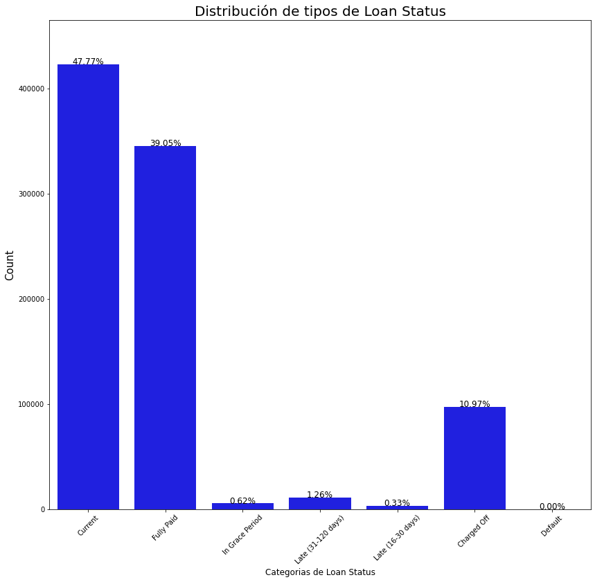

```python
total = len(lendingclub)
plt.figure(figsize = (14,13))
g = sns.countplot(x="loan_status", data=lendingclub,
                  color='blue')
g.set_xticklabels(g.get_xticklabels(),rotation=45)
g.set_xlabel("Categorias de Loan Status", fontsize=12)
g.set_ylabel("Count", fontsize=15)
g.set_title("Distribución de tipos de Loan Status", fontsize=20)
sizes=[]
for p in g.patches:
    height = p.get_height()
    sizes.append(height)
    g.text(p.get_x()+p.get_width()/2.,
            height + 3,
            '{:1.2f}%'.format(height/total*100),
            ha="center", fontsize=12)
g.set_ylim(0, max(sizes) * 1.10)
plt.show()
```

### Propósito del crédito

Propósito del crédito es una categoría proporcionada por el prestatario para la solicitud de préstamo. Como es una característica categórica que dice cuál es el propósito del préstamo, sería interesante comenzar por esta variable.

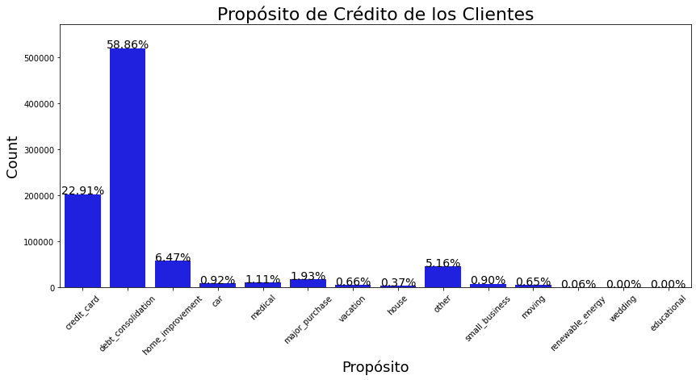

```python
plt.figure(figsize=(14,6))

g = sns.countplot(x='purpose', data=lendingclub,
                  color='blue')
g.set_title("Propósito de Crédito de los Clientes", fontsize=22)
g.set_xlabel("Propósito", fontsize=18)
g.set_ylabel('Count', fontsize=18)

sizes=[]

for p in g.patches:
    height = p.get_height()
    sizes.append(height)
    g.text(p.get_x()+p.get_width()/2.,
            height + 3,
            '{:1.2f}%'.format(height/total*100),
            ha="center", fontsize=14)

g.set_ylim(0, max(sizes) * 1.10)
g.set_xticklabels(g.get_xticklabels(),
                  rotation=45)

plt.show()
```

### Distribuciones de la cantidad del préstamo y tipo de interés

El monto indicado del préstamo solicitado por el prestatario. Si en algún momento, el departamento de crédito reduce el monto del préstamo, entonces se reflejará en este valor. `intRate` es la tasa de interés del préstamo.

[figure not shown]

```python
int_numeric = lendingclub["int_rate"].str.strip("%")
int_numeric = pd.to_numeric(int_numeric)
lendingclub["int_rate"] = int_numeric/100

lendingclub['int_round'] = lendingclub['int_rate'].round(0).astype(int)

#I will start looking the loan_amnt column
plt.figure(figsize=(14,10))

# Loan Amt plot
plt.subplot(211)
g = sns.distplot(lendingclub["loan_amnt"])
g.set_xlabel("Loan Amount Value", fontsize=16)
g.set_ylabel("Frequency", fontsize=16)
g.set_title("Loan Amount Distribuition", fontsize=20)

## Interest plot
plt.subplot(212)
g1 = sns.countplot(x="int_round", data=lendingclub,
                  color='blue')
g1.set_xlabel("Loan Interest Rate", fontsize=16)
g1.set_ylabel("Count", fontsize=16)
g1.set_title("Interest Rate Distribuition", fontsize=20)
sizes=[] # Get highest values in y
for p in g1.patches:
    height = p.get_height()
    sizes.append(height)
    g1.text(p.get_x()+p.get_width()/2.,
            height + 3,
            '{:1.2f}%'.format(height/total*100),
            ha="center", fontsize=12)
g1.set_ylim(0, max(sizes) * 1.10) # set y limit based on highest heights

plt.subplots_adjust(hspace = 0.4,top = 0.9)

plt.show()
```

### Estado de verificación

Indica si el ingreso conjunto de los coprestatarios fue verificado por Lending Club, no verificado, o si se verificó la fuente de ingresos.

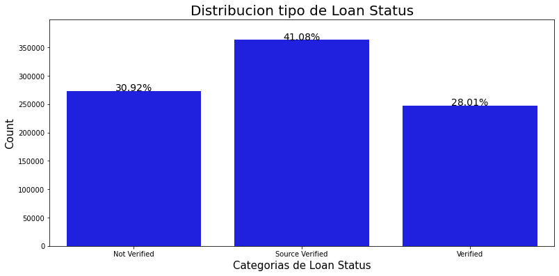

```python
plt.figure(figsize = (13,6))

g = sns.countplot(x="verification_status", data=lendingclub,
                  color='blue')
g.set_xlabel("Categorias de Loan Status", fontsize=15)
g.set_ylabel("Count", fontsize=15)
g.set_title("Distribucion tipo de Loan Status", fontsize=20)
sizes=[]
for p in g.patches:
    height = p.get_height()
    sizes.append(height)
    g.text(p.get_x()+p.get_width()/2.,
            height + 3,
            '{:1.2f}%'.format(height/total*100),
            ha="center", fontsize=14)
g.set_ylim(0, max(sizes) * 1.10)

plt.show()
```

### Columna de pagos

El pago mensual adeudado por el prestatario si se origina el préstamo. Con esta información, podemos investigar la diferencia entre `emp_title` o regiones, para encontrar algunos patrones de valores interesantes para el estudio.

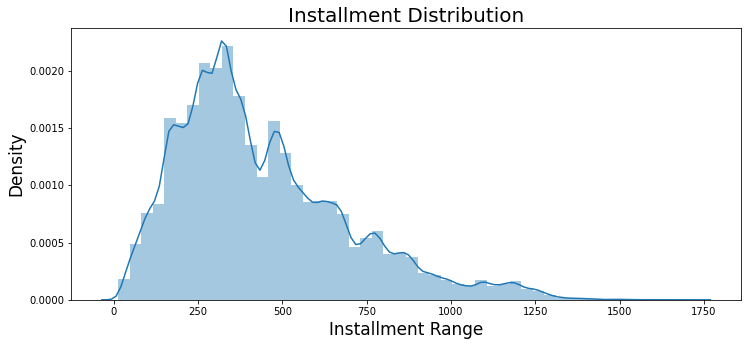

```python
plt.figure(figsize=(12,5))

sns.distplot(lendingclub['installment'])
plt.title("Installment Distribution", fontsize=20)
plt.xlabel("Installment Range", fontsize=17)
plt.ylabel("Density", fontsize=17)

plt.show()
```

### Pagos según el Loan Status

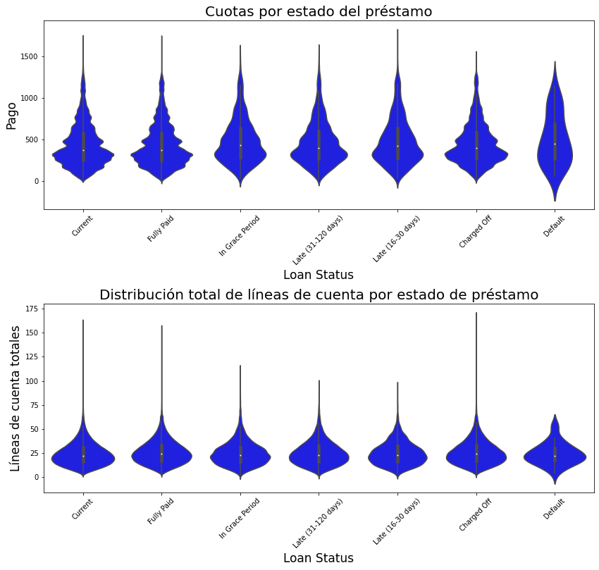

```python
plt.figure(figsize = (14,12))

plt.subplot(211)
g = sns.violinplot(x='loan_status', y="installment",
                   data=lendingclub, color='blue')
g.set_xticklabels(g.get_xticklabels(),rotation=45)
g.set_xlabel("Loan Status", fontsize=17)
g.set_ylabel("Pago", fontsize=17)
g.set_title("Cuotas por estado del préstamo", fontsize=20)

plt.subplot(212)
g1 = sns.violinplot(x='loan_status', y="total_acc",
                   data=lendingclub, color='blue')
g1.set_xticklabels(g.get_xticklabels(),rotation=45)
g1.set_xlabel("Loan Status", fontsize=17)
g1.set_ylabel("Líneas de cuenta totales", fontsize=17)
g1.set_title("Distribución total de líneas de cuenta por estado de préstamo", fontsize=20)

plt.subplots_adjust(hspace = 0.5,top = 0.9)

plt.show()
```

### Grades

Una de las variables que encontramos relevantes para realizar los modelos es `Grades`, por ello vamos a estudiarla.

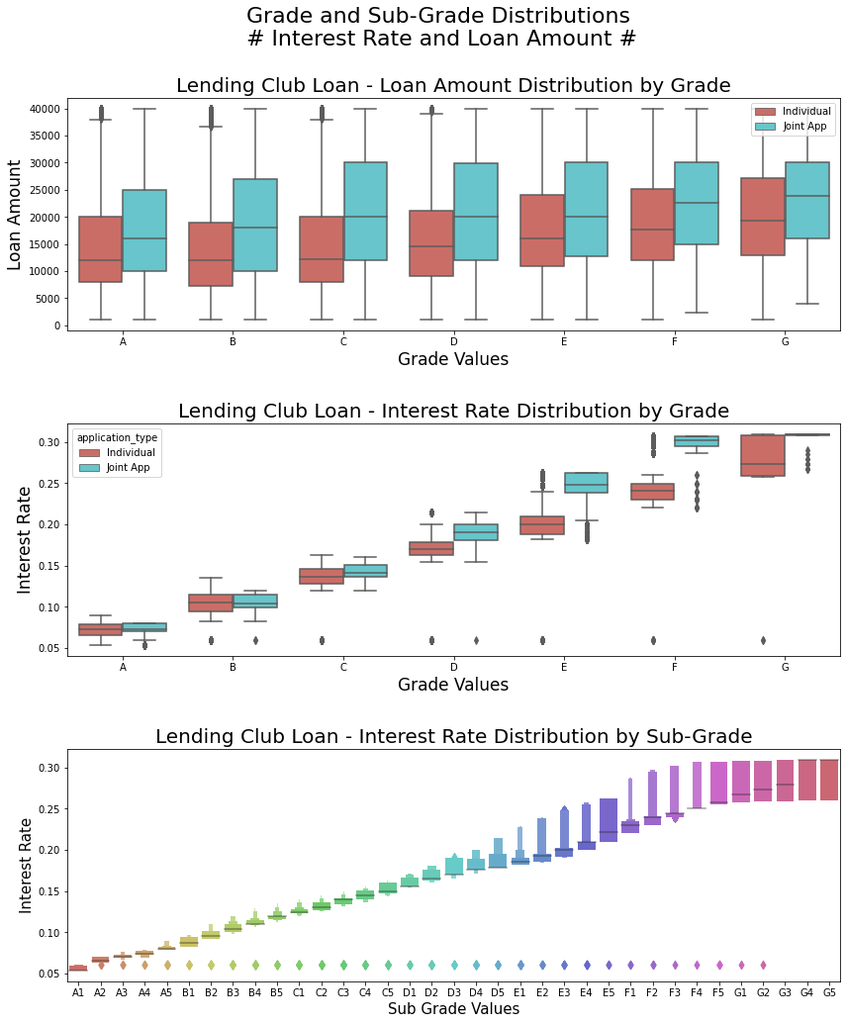

```python
order_sub = lendingclub.groupby("sub_grade")['int_rate'].count().index

plt.figure(figsize=(14,16))

plt.suptitle('Grade and Sub-Grade Distributions \n# Interest Rate and Loan Amount #', fontsize=22)

plt.subplot(311)
g = sns.boxplot(x="grade", y="loan_amnt", data=lendingclub,
                palette="hls", hue="application_type",
                order=["A",'B','C','D','E','F', 'G'])
g.set_xlabel("Grade Values", fontsize=17)
g.set_ylabel("Loan Amount", fontsize=17)
g.set_title("Lending Club Loan - Loan Amount Distribution by Grade", fontsize=20)
g.legend(loc='upper right')

plt.subplot(312)
g1 = sns.boxplot(x='grade', y="int_rate",data=lendingclub,
               hue="application_type", palette = "hls",
               order=["A",'B','C','D','E','F', 'G'])
g1.set_xlabel("Grade Values", fontsize=17)
g1.set_ylabel("Interest Rate", fontsize=17)
g1.set_title("Lending Club Loan - Interest Rate Distribution by Grade", fontsize=20)

plt.subplot(313)
g2 = sns.boxenplot(x="sub_grade", y="int_rate", data=lendingclub,
                   palette="hls", order=order_sub)
g2.set_xlabel("Sub Grade Values", fontsize=15)
g2.set_ylabel("Interest Rate", fontsize=15)
g2.set_title("Lending Club Loan - Interest Rate Distribution by Sub-Grade", fontsize=20)

plt.subplots_adjust(hspace = 0.4,top = 0.9)

plt.show()
```

### Terms

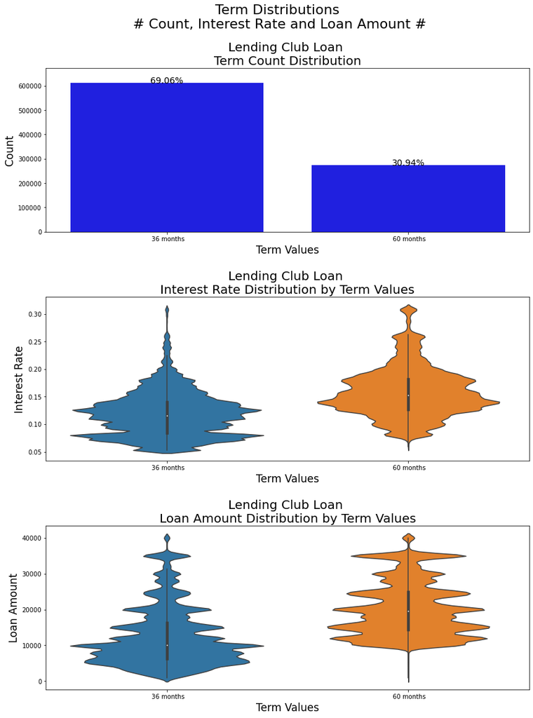

```python
order_sub = lendingclub.groupby("sub_grade")['int_rate'].count().index

plt.figure(figsize=(14,18))

plt.suptitle('Term Distributions \n# Count, Interest Rate and Loan Amount #', fontsize=22)

plt.subplot(311)
g = sns.countplot(x="term", data=lendingclub,color='blue')
g.set_xlabel("Term Values", fontsize=17)
g.set_ylabel("Count", fontsize=17)
g.set_title("Lending Club Loan \nTerm Count Distribution", fontsize=20)
sizes=[]
for p in g.patches:
    height = p.get_height()
    sizes.append(height)
    g.text(p.get_x()+p.get_width()/2.,
            height + 3,
            '{:1.2f}%'.format(height/total*100),
            ha="center", fontsize=14)
g.set_ylim(0, max(sizes) * 1.10)

plt.subplot(312)
g1 = sns.violinplot(x='term', y="int_rate",data=lendingclub )
g1.set_xlabel("Term Values", fontsize=17)
g1.set_ylabel("Interest Rate", fontsize=17)
g1.set_title("Lending Club Loan \nInterest Rate Distribution by Term Values", fontsize=20)

plt.subplot(313)
g2 = sns.violinplot(x="term", y="loan_amnt", data=lendingclub)
g2.set_xlabel("Term Values", fontsize=17)
g2.set_ylabel("Loan Amount", fontsize=17)
g2.set_title("Lending Club Loan \nLoan Amount Distribution by Term Values", fontsize=20)

plt.subplots_adjust(hspace = 0.4, top = 0.9)

plt.show()
```

## Data engineering y selección de variables

### Variables con NA

En primer lugar, quitamos todos aquellas variables con un número considerable de valores perdidos que pueden influir negativamente en nuestros modelos. En este caso consideramos quitar todas aquellas variables con más de 431,425 NA. Podemos observar el número de missing values en la siguiente tabla.

```python
na_columnas = pd.DataFrame(lendingclub.isna().sum(), columns = ['Valores NaN']).sort_values(['Valores NaN'], ascending = False)
pd.set_option('display.max_rows', na_columnas.shape[0]+1)
na_columnas
```

|  | Valores NaN |
| --- | --- |
| member_id | 884876 |
| orig_projected_additional_accrued_interest | 882607 |
| hardship_payoff_balance_amount | 882215 |
| hardship_type | 882215 |
| hardship_reason | 882215 |
| hardship_status | 882215 |
| hardship_amount | 882215 |
| hardship_start_date | 882215 |
| hardship_end_date | 882215 |
| payment_plan_start_date | 882215 |
| hardship_length | 882215 |
| hardship_dpd | 882215 |
| hardship_loan_status | 882215 |
| deferral_term | 882215 |
| hardship_last_payment_amount | 882215 |
| sec_app_mths_since_last_major_derog | 877691 |
| settlement_term | 876356 |
| debt_settlement_flag_date | 876356 |
| settlement_status | 876356 |
| settlement_date | 876356 |
| settlement_amount | 876356 |
| settlement_percentage | 876356 |
| desc | 869552 |
| sec_app_revol_util | 864358 |
| sec_app_fico_range_high | 864076 |
| sec_app_open_acc | 864076 |
| sec_app_open_act_il | 864076 |
| sec_app_num_rev_accts | 864076 |
| sec_app_chargeoff_within_12_mths | 864076 |
| sec_app_earliest_cr_line | 864076 |

[output cut: 122 more lines]

```python
lendingclub1 = lendingclub.dropna(thresh=len(lendingclub) - 431425, axis=1)
```

Comporobamos

```python
na_columnas1  = pd.DataFrame(lendingclub1.isna().sum(), columns = ['Valores NaN']).sort_values(['Valores NaN'], ascending = False)
pd.set_option('display.max_rows', na_columnas1.shape[0]+1)
na_columnas1
```

|  | Valores NaN |
| --- | --- |
| mths_since_recent_inq | 92130 |
| emp_title | 52693 |
| emp_length | 51193 |
| num_tl_120dpd_2m | 37803 |
| mo_sin_old_il_acct | 25614 |
| bc_util | 9824 |
| percent_bc_gt_75 | 9680 |
| bc_open_to_buy | 9287 |
| mths_since_recent_bc | 8763 |
| last_pymnt_d | 758 |
| revol_util | 489 |
| dti | 261 |
| title | 132 |
| last_credit_pull_d | 38 |
| avg_cur_bal | 13 |
| num_rev_accts | 1 |
| mort_acc | 0 |
| mo_sin_rcnt_tl | 0 |
| id | 0 |
| delinq_amnt | 0 |
| mo_sin_rcnt_rev_tl_op | 0 |
| mo_sin_old_rev_tl_op | 0 |
| num_actv_bc_tl | 0 |
| chargeoff_within_12_mths | 0 |
| acc_open_past_24mths | 0 |
| total_rev_hi_lim | 0 |
| tot_cur_bal | 0 |
| num_accts_ever_120_pd | 0 |
| num_il_tl | 0 |
| num_actv_rev_tl | 0 |

[output cut: 64 more lines]

Guardamos este dataset por si nos hiciese falta en un futuro del trabajo

```python
lendingclub1.to_csv('./data/02_intermidiate_general.csv', index = False)
```

A continuación, vamos a observar las variables de tipo object y ver cuantos tipos de valores contienen.

```python
lendingclub1.select_dtypes("object").nunique().sort_values()
```

```
debt_settlement_flag         2
term                         2
hardship_flag                2
application_type             2
initial_list_status          2
pymnt_plan                   2
disbursement_method          2
verification_status          3
home_ownership               5
grade                        7
loan_status                  7
emp_length                  11
purpose                     14
issue_d                     30
sub_grade                   35
last_pymnt_d                47
last_credit_pull_d          48
addr_state                  51
earliest_cr_line           712
zip_code                   933
revol_util                1271
title                     2071
emp_title               214509
url                     884876
id                      884876
dtype: int64
```

Observamos que hay muchos tipos de valores en `url`, lo que podría ser un impedimento a la hora de realizar nuestro modelos así como escasa aportación de información a la hora de determinar el `loan_status`.

Y vemos los NA que contienen

```python
lendingclub1.select_dtypes("object").isna().sum()
```

```
id                          0
term                        0
grade                       0
sub_grade                   0
emp_title               52693
emp_length              51193
home_ownership              0
verification_status         0
issue_d                     0
loan_status                 0
pymnt_plan                  0
url                         0
purpose                     0
title                     132
zip_code                    0
addr_state                  0
earliest_cr_line            0
revol_util                489
initial_list_status         0
last_pymnt_d              758
last_credit_pull_d         38
application_type            0
hardship_flag               0
disbursement_method         0
debt_settlement_flag        0
dtype: int64
```

A continuación, mirando la información que nos puede aportar cada variable a la hora de ver si otorgamos un préstamo o no a un cliente, hemos considerado una serie de variables que no resultan relevantes para el objetivo de este trabajo.

```python
lendigclub_v2 = lendingclub1.drop(['id',
 'funded_amnt',
 'funded_amnt_inv',
 'installment',
 'emp_title',
 'emp_length',
 'issue_d',
  "zip_code",
 'pymnt_plan',
 'url',
 'title',
 'addr_state',
 'dti',
 'earliest_cr_line',
 'fico_range_low',
 'fico_range_high',
 'inq_last_6mths',
 'pub_rec',
 'initial_list_status',
 'out_prncp_inv',
 'total_pymnt',
 'total_pymnt_inv',
 'total_rec_late_fee',
 'last_pymnt_d',
 'last_pymnt_amnt',
 'last_credit_pull_d',
 'last_fico_range_high',
 'last_fico_range_low',
 'policy_code',
 'application_type',
 'bc_open_to_buy',
 'mo_sin_old_il_acct',
 'mo_sin_rcnt_rev_tl_op',
 'mo_sin_rcnt_tl',
 'mths_since_recent_bc',
 'num_actv_bc_tl',
 'num_bc_sats',
 'num_rev_accts',
 'num_tl_120dpd_2m',
 'num_tl_90g_dpd_24m',
 'num_tl_op_past_12m',
 'pct_tl_nvr_dlq',
 'disbursement_method',
 'debt_settlement_flag',
  "mths_since_recent_inq",
"bc_util",
 "percent_bc_gt_75",
 "revol_util",
"avg_cur_bal" ], axis = 1)
```

### Tratamiento de variables categóricas

La varaible `term` Contiene valores categóricas que habría que pasar a numéricos

```python
sin_months = lendigclub_v2["term"].str.strip("months")
sin_months = pd.to_numeric(sin_months)
lendigclub_v2["term"] = sin_months
```

Comprobamos que se han cambiado de tipo

```python
lendigclub_v2.info()
```

```
<class 'pandas.core.frame.DataFrame'>
Int64Index: 884876 entries, 0 to 421094
Data columns (total 45 columns):
 #   Column                      Non-Null Count   Dtype
---  ------                      --------------   -----
 0   loan_amnt                   884876 non-null  float64
 1   term                        884876 non-null  int64
 2   int_rate                    884876 non-null  float64
 3   grade                       884876 non-null  object
 4   sub_grade                   884876 non-null  object
 5   home_ownership              884876 non-null  object
 6   annual_inc                  884876 non-null  float64
 7   verification_status         884876 non-null  object
 8   loan_status                 884876 non-null  object
 9   purpose                     884876 non-null  object
```

[output cut: 37 more lines]

### Transformación de dummies

```python
X = lendigclub_v2.drop(['loan_status'], axis=1)
encoded_all = pd.get_dummies(X)
df_c = pd.concat([encoded_all, lendigclub_v2['loan_status']], axis=1)
df_c_prueba_sin_current = df_c[df_c["loan_status"]!="Current"]
```

### Transformación de la variable Target

Vemos que en nuestra variable target tenemos 7 valores posibles, para este trabajo haremos un encode entre las que sean Fully Paid y el resto de variables. Por lo tanto las que sean Fully Paid tendrán como valor el 1 y el resto tomarán el valor 0.

En resumen, vamos a diferenciar entre los clientes que pagan y no pagan. Diferenciamos entre:

```python
lendingclub1["loan_status"].value_counts()
```

```
Current               422685
Fully Paid            345520
Charged Off            97047
Late (31-120 days)     11168
In Grace Period         5507
Late (16-30 days)       2915
Default                   34
Name: loan_status, dtype: int64
```

```python
df_c_prueba_sin_current['loan_status'].mask(df_c_prueba_sin_current['loan_status'] == 'Fully Paid', '1', inplace=True)
df_c_prueba_sin_current['loan_status'].mask(df_c_prueba_sin_current['loan_status'] != '1', '0', inplace=True)
```

### Dataset final para realizar modelos

```python
df_c_prueba_sin_current.to_csv('./data/03_processed.csv', index = False)
```